# Empathy in Real vs. Synthetic Clinician Comments (Pilot 2)

## 1 Summary

Across 3 synthetic models (Gemini, Grok, Openai) and 3 prompting methods (DG, SAG, SAGII), real comments generally show significantly higher empathy ratings across all three mechanisms (Emotional Reactions, Explorations, Interpretations), with one exception: for Interpretations, Grok scores significantly *higher* than real across all three prompting strategies (DG/SAG/SAGII).

## 2 Data

3000 Reddit posts were used, each paired with its real clinician comment(s) and synthetic comments from 3 models x 3 prompting methods. 62161 comments were classified in total: 3882 real and 58279 synthetic (6475 per model/method group on average). Predicted empathy comes from the same three fine-tuned RoBERTa bi-encoder classifiers used in pilot 1 (Emotional Reactions, Interpretations, Explorations; see `../2_training`), each producing an ordinal label: 0 = none, 1 = weak, 2 = strong.

## 3 Mean predicted empathy by group

Empathy labels are ordinal (0 = none, 1 = weak, 2 = strong). The means shown below implicitly treat the labels as equally spaced, and are shown only as a quick, monotonic summary (Fig. 1). The actual label distribution (the ordinal-honest view) is plotted underneath it as proportions per group (Fig. 2).

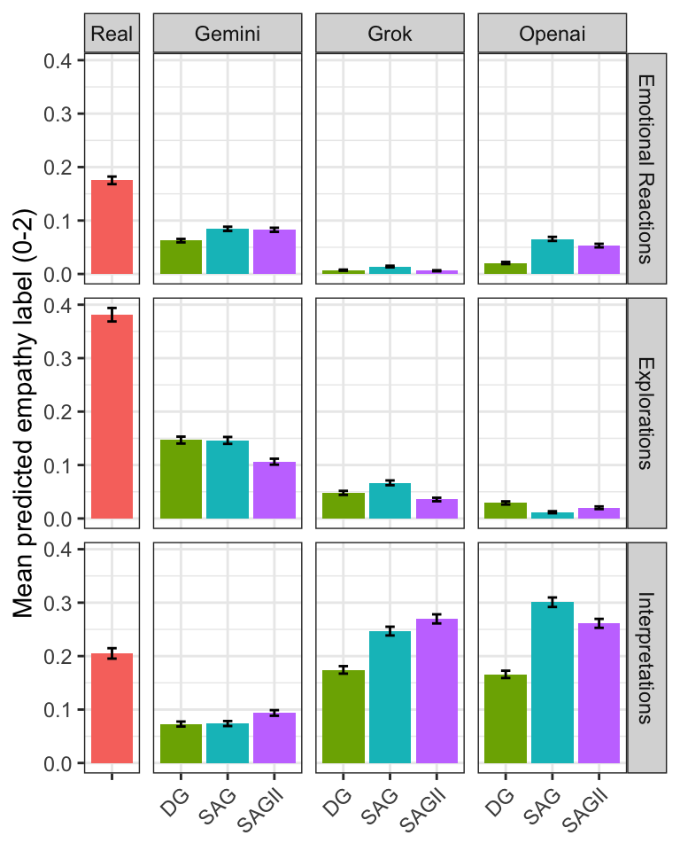

Figure 1: Average predicted empathy per population.

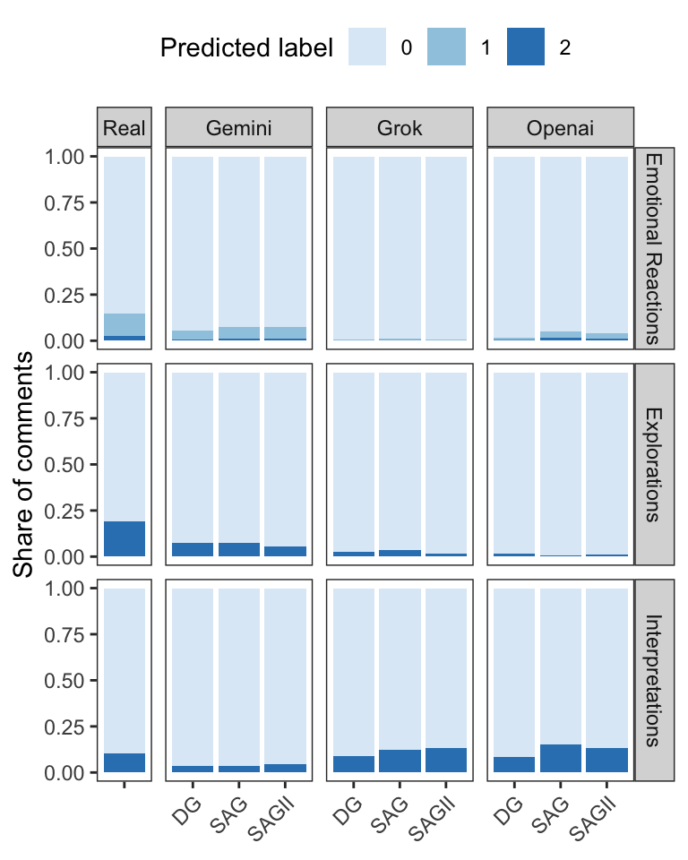

Figure 2: Stacked predicted label proportions per population.

Table 1: Predicted label proportions by group (same data as Fig. 2, as a table)—useful for spotting cells too sparse to trust, e.g. where P(label=1) is 0.

| Mechanism | Model | Method | n | P(label=0) | P(label=1) | P(label=2) |
| --- | --- | --- | --- | --- | --- | --- |
| Emotional Reactions | Real |  | 3882 | 0.850 | 0.124 | 0.026 |
|  | Gemini | DG | 6476 | 0.943 | 0.053 | 0.005 |
|  |  | SAG | 6476 | 0.927 | 0.061 | 0.012 |
|  |  | SAGII | 6474 | 0.927 | 0.063 | 0.010 |
|  | Grok | DG | 6475 | 0.993 | 0.007 | 0.000 |
|  |  | SAG | 6475 | 0.987 | 0.012 | 0.001 |
|  |  | SAGII | 6475 | 0.994 | 0.006 | 0.000 |
|  | Openai | DG | 6476 | 0.982 | 0.015 | 0.003 |
|  |  | SAG | 6476 | 0.950 | 0.034 | 0.016 |
|  |  | SAGII | 6476 | 0.958 | 0.031 | 0.011 |
| Explorations | Real |  | 3882 | 0.809 | 0.000 | 0.191 |
|  | Gemini | DG | 6476 | 0.927 | 0.000 | 0.073 |
|  |  | SAG | 6476 | 0.927 | 0.000 | 0.073 |
|  |  | SAGII | 6474 | 0.947 | 0.000 | 0.053 |
|  | Grok | DG | 6475 | 0.976 | 0.000 | 0.024 |
|  |  | SAG | 6475 | 0.967 | 0.000 | 0.033 |
|  |  | SAGII | 6475 | 0.982 | 0.000 | 0.018 |
|  | Openai | DG | 6476 | 0.985 | 0.000 | 0.015 |
|  |  | SAG | 6476 | 0.994 | 0.000 | 0.006 |
|  |  | SAGII | 6476 | 0.990 | 0.000 | 0.010 |
| Interpretations | Real |  | 3882 | 0.897 | 0.000 | 0.103 |
|  | Gemini | DG | 6476 | 0.964 | 0.000 | 0.036 |
|  |  | SAG | 6476 | 0.963 | 0.000 | 0.037 |
|  |  | SAGII | 6474 | 0.953 | 0.000 | 0.047 |
|  | Grok | DG | 6475 | 0.913 | 0.000 | 0.087 |
|  |  | SAG | 6475 | 0.877 | 0.000 | 0.123 |
|  |  | SAGII | 6475 | 0.865 | 0.000 | 0.135 |
|  | Openai | DG | 6476 | 0.917 | 0.000 | 0.083 |
|  |  | SAG | 6476 | 0.850 | 0.000 | 0.150 |
|  |  | SAGII | 6476 | 0.869 | 0.000 | 0.131 |

## 4 Real vs. synthetic (Mann-Whitney U, Benjamini-Hochberg adjusted)

Table 2 shows that all real-vs-synthetic contrasts are significant, such that real ones score significantly higher. Notable exceptions, where the synthetic ones score higher are marked in red.

Table 2: Mann-Whitney U test.

| Mechanism | Model | Method | Mean (real) | Mean (synthetic) | p | p (BH-adj.) | Rank-biserial r |
| --- | --- | --- | --- | --- | --- | --- | --- |
| Emotional Reactions | Gemini | DG | 0.175 | 0.062 | 0.0000 | 0.0000 | 0.093 |
|  |  | SAG | 0.175 | 0.084 | 0.0000 | 0.0000 | 0.077 |
|  |  | SAGII | 0.175 | 0.083 | 0.0000 | 0.0000 | 0.077 |
|  | Grok | DG | 0.175 | 0.007 | 0.0000 | 0.0000 | 0.143 |
|  |  | SAG | 0.175 | 0.014 | 0.0000 | 0.0000 | 0.137 |
|  |  | SAGII | 0.175 | 0.006 | 0.0000 | 0.0000 | 0.144 |
|  | Openai | DG | 0.175 | 0.021 | 0.0000 | 0.0000 | 0.132 |
|  |  | SAG | 0.175 | 0.066 | 0.0000 | 0.0000 | 0.099 |
|  |  | SAGII | 0.175 | 0.053 | 0.0000 | 0.0000 | 0.107 |
| Explorations | Gemini | DG | 0.381 | 0.147 | 0.0000 | 0.0000 | 0.117 |
|  |  | SAG | 0.381 | 0.146 | 0.0000 | 0.0000 | 0.118 |
|  |  | SAGII | 0.381 | 0.106 | 0.0000 | 0.0000 | 0.137 |
|  | Grok | DG | 0.381 | 0.048 | 0.0000 | 0.0000 | 0.167 |
|  |  | SAG | 0.381 | 0.067 | 0.0000 | 0.0000 | 0.157 |
|  |  | SAGII | 0.381 | 0.036 | 0.0000 | 0.0000 | 0.173 |
|  | Openai | DG | 0.381 | 0.029 | 0.0000 | 0.0000 | 0.176 |
|  |  | SAG | 0.381 | 0.012 | 0.0000 | 0.0000 | 0.185 |
|  |  | SAGII | 0.381 | 0.020 | 0.0000 | 0.0000 | 0.181 |
| Interpretations | Gemini | DG | 0.205 | 0.073 | 0.0000 | 0.0000 | 0.066 |
|  |  | SAG | 0.205 | 0.074 | 0.0000 | 0.0000 | 0.066 |
|  |  | SAGII | 0.205 | 0.094 | 0.0000 | 0.0000 | 0.056 |
|  | Grok | DG | 0.205 | 0.174 | 0.0089 | 0.0089 | 0.015 |
|  |  | SAG | 0.205 | 0.247 | 0.0013 | 0.0013 | -0.021 |
|  |  | SAGII | 0.205 | 0.270 | 0.0000 | 0.0000 | -0.032 |
|  | Openai | DG | 0.205 | 0.166 | 0.0008 | 0.0008 | 0.020 |
|  |  | SAG | 0.205 | 0.301 | 0.0000 | 0.0000 | -0.048 |
|  |  | SAGII | 0.205 | 0.261 | 0.0000 | 0.0000 | -0.028 |

## 5 Mixed-effects models

The Mann-Whitney tests above treat every comment as independent, but they aren’t: several synthetic comments (and sometimes several real ones) come from the *same* Reddit thread, so they share whatever makes that particular topic more or less emotionally charged or explorable. To account for that, we run two mixed-effects models per mechanism:

- **A - omnibus** (`label ~ group + log(length) + (1|post_id)`, all 62161 comments): tests whether the 10-level group factor (real + 9 model/method combinations) matters at all.
- **B - model × method** (`label ~ model * method + log(length) + (1|post_id)`, synthetic comments only - “real” has no model/method to cross): tests the model main effect, the method main effect, and whether they interact.

**Emotional Reactions** uses all 3 empathy levels, so it’s fit as a cumulative link mixed model (`ordinal::clmm`). **Interpretations** and **Explorations** never predict label 1 anywhere in this data (0 occurrences out of 62161 comments, checked directly), so a 3-level ordinal model would be degenerate for them—they’re fit instead as binomial mixed models (`lme4::glmer`) on P(label = 2).

Table 3: Convergence status for each fitted model.

| Mechanism | Model | Type | Converged | Note |
| --- | --- | --- | --- | --- |
| Emotional Reactions | A_group_omnibus | clmm | FALSE | max\|grad\| = 0.00905 (didn’t fully settle) |
| Emotional Reactions | B_model_x_method | clmm | FALSE | max\|grad\| = 0.00131 (didn’t fully settle) |
| Interpretations | A_group_omnibus | glmer | TRUE | NA |
| Interpretations | B_model_x_method | glmer | TRUE | NA |
| Explorations | A_group_omnibus | glmer | TRUE | NA |
| Explorations | B_model_x_method | glmer | TRUE | NA |

**Emotional Reactions’s models did not fully converge** (max|grad| = 0.00905 (didn’t fully settle) for model A, max|grad| = 0.00131 (didn’t fully settle) for model B). Both gradients are small (no diverging coefficients, no crash), consistent with the known separation risk in `grok_sagii` (0/6475 comments at label 2 for that combination) rather than a broken model. Accordingly, ER’s results below are worth treating as directionally informative rather than fully settled; IP and EX converged cleanly.

Table 4: Model A: omnibus test for group (real + 9 model/method combinations), replacing Kruskal-Wallis.

| Mechanism | Chi-sq | df | p |
| --- | --- | --- | --- |
| Emotional Reactions | 1744.8 | 9 | 0 |
| Interpretations | 1241.7 | 9 | 0 |
| Explorations | 2035.2 | 9 | 0 |

The group effect is significant for all three mechanisms (Table 4). Comment length (log-transformed) is included as a covariate in both models and is a significant predictor everywhere (Model A: all three $p < 0.001$), but not in the same direction: Emotional Reactions (longer), Interpretations (longer) score higher with more words, while Explorations scores *lower* with more words—plausibly because exploratory, question-asking replies tend to be short follow-ups rather than long ones.

Table 5: Table 6: Model A: each (model, method) group vs. real (OR below 1 = lower odds of higher empathy than real; rows with OR above 1 shaded).

| Mechanism | Group | Odds ratio | OR 95% LCL | OR 95% UCL | p (BH-adj.) |
| --- | --- | --- | --- | --- | --- |
| Emotional Reactions | gemini_dg | 0.272 | 0.232 | 0.320 | 0 |
| Emotional Reactions | openai_dg | 0.050 | 0.040 | 0.062 | 0 |
| Emotional Reactions | grok_dg | 0.027 | 0.019 | 0.037 | 0 |
| Emotional Reactions | gemini_sag | 0.355 | 0.305 | 0.412 | 0 |
| Emotional Reactions | openai_sag | 0.137 | 0.115 | 0.163 | 0 |
| Emotional Reactions | grok_sag | 0.045 | 0.035 | 0.057 | 0 |
| Emotional Reactions | gemini_sagii | 0.333 | 0.286 | 0.386 | 0 |
| Emotional Reactions | openai_sagii | 0.109 | 0.091 | 0.131 | 0 |
| Emotional Reactions | grok_sagii | 0.020 | 0.014 | 0.028 | 0 |
| Interpretations | gemini_dg | 0.628 | 0.514 | 0.767 | 0 |
| Interpretations | openai_dg | 0.612 | 0.522 | 0.718 | 0 |
| Interpretations | grok_dg | 2.106 | 1.760 | 2.520 | 0 |
| Interpretations | gemini_sag | 0.555 | 0.455 | 0.676 | 0 |
| Interpretations | openai_sag | 0.693 | 0.596 | 0.805 | 0 |
| Interpretations | grok_sag | 2.213 | 1.877 | 2.608 | 0 |
| Interpretations | gemini_sagii | 0.599 | 0.498 | 0.721 | 0 |
| Interpretations | openai_sagii | 0.580 | 0.498 | 0.675 | 0 |
| Interpretations | grok_sagii | 2.835 | 2.401 | 3.349 | 0 |
| Explorations | gemini_dg | 0.185 | 0.159 | 0.215 | 0 |
| Explorations | openai_dg | 0.032 | 0.025 | 0.041 | 0 |
| Explorations | grok_dg | 0.044 | 0.036 | 0.054 | 0 |
| Explorations | gemini_sag | 0.193 | 0.166 | 0.224 | 0 |
| Explorations | openai_sag | 0.015 | 0.011 | 0.022 | 0 |
| Explorations | grok_sag | 0.073 | 0.060 | 0.087 | 0 |
| Explorations | gemini_sagii | 0.134 | 0.114 | 0.157 | 0 |
| Explorations | openai_sagii | 0.027 | 0.020 | 0.036 | 0 |
| Explorations | grok_sagii | 0.034 | 0.028 | 0.043 | 0 |

Table 5: real scores significantly higher than every synthetic group for Emotional Reactions and Explorations. Interpretations is the exception—Grok scores significantly *higher* than real for all three prompting strategies, while Gemini and OpenAI still score lower.

This Grok/OpenAI split isn’t what the raw Mann-Whitney table shows (there, `grok_dg` was lower and `openai_sag`/`openai_sagii` were higher—the opposite pattern). Refitting without `log(length)` reproduces the raw pattern almost exactly, so this looks like a length confound: OpenAI writes much longer comments than Grok, and length strongly predicts this label, so part of OpenAI’s raw advantage—and part of Grok’s raw shortfall with DG—is just comment length.

Table 7: Model B: model, method, and model x method tests (synthetic comments only), replacing the pooled by-method/by-model comparisons.

| Mechanism | Term | Chi-sq | df | p |
| --- | --- | --- | --- | --- |
| Emotional Reactions | model | 865.8 | 2 | 0.0000 |
| Emotional Reactions | method | 50.2 | 2 | 0.0000 |
| Emotional Reactions | model:method | 37.7 | 4 | 0.0000 |
| Interpretations | model | 1278.7 | 2 | 0.0000 |
| Interpretations | method | 1.6 | 2 | 0.4529 |
| Interpretations | model:method | 41.8 | 4 | 0.0000 |
| Explorations | model | 591.4 | 2 | 0.0000 |
| Explorations | method | 49.0 | 2 | 0.0000 |
| Explorations | model:method | 52.4 | 4 | 0.0000 |

The model x method interaction is significant for all three mechanisms, i.e. the effect of a prompting method genuinely depends on which model generated it. The one main effect that drops out is **Interpretations’s method effect** (p = 0.45): once model is accounted for, which prompting method was used doesn’t matter on its own for Interpretations.

Since the interaction is significant everywhere, pooled main-effect means (averaged over the other factor) would be misleading here - e.g. a model’s “average” effect can look muted if it does well with one method and poorly with another. Instead, two sets of simple-effects contrasts: models compared within each method, and methods compared within each model.

Table 8: Model B: pairwise model contrasts within each method.

| Mechanism | Method | Contrast | Odds ratio | OR 95% LCL | OR 95% UCL | p (BH-adj.) |
| --- | --- | --- | --- | --- | --- | --- |
| Emotional Reactions | dg | gemini / openai | 5.953 | 4.603 | 7.700 | 0.0000 |
| Emotional Reactions | dg | gemini / grok | 11.030 | 7.927 | 15.348 | 0.0000 |
| Emotional Reactions | dg | openai / grok | 1.853 | 1.252 | 2.741 | 0.0023 |
| Emotional Reactions | sag | gemini / openai | 2.791 | 2.181 | 3.572 | 0.0000 |
| Emotional Reactions | sag | gemini / grok | 8.605 | 6.684 | 11.079 | 0.0000 |
| Emotional Reactions | sag | openai / grok | 3.083 | 2.241 | 4.243 | 0.0000 |
| Emotional Reactions | sagii | gemini / openai | 3.300 | 2.597 | 4.195 | 0.0000 |
| Emotional Reactions | sagii | gemini / grok | 18.314 | 12.928 | 25.944 | 0.0000 |
| Emotional Reactions | sagii | openai / grok | 5.549 | 3.687 | 8.351 | 0.0000 |
| Interpretations | dg | gemini / openai | 1.424 | 1.178 | 1.721 | 0.0003 |
| Interpretations | dg | gemini / grok | 0.279 | 0.236 | 0.330 | 0.0000 |
| Interpretations | dg | openai / grok | 0.196 | 0.165 | 0.232 | 0.0000 |
| Interpretations | sag | gemini / openai | 1.241 | 1.023 | 1.505 | 0.0294 |
| Interpretations | sag | gemini / grok | 0.252 | 0.215 | 0.296 | 0.0000 |
| Interpretations | sag | openai / grok | 0.203 | 0.174 | 0.238 | 0.0000 |
| Interpretations | sagii | gemini / openai | 1.504 | 1.262 | 1.792 | 0.0000 |
| Interpretations | sagii | gemini / grok | 0.191 | 0.165 | 0.221 | 0.0000 |
| Interpretations | sagii | openai / grok | 0.127 | 0.108 | 0.150 | 0.0000 |
| Explorations | dg | gemini / openai | 3.830 | 2.968 | 4.943 | 0.0000 |
| Explorations | dg | gemini / grok | 5.918 | 4.783 | 7.323 | 0.0000 |
| Explorations | dg | openai / grok | 1.545 | 1.147 | 2.081 | 0.0045 |
| Explorations | sag | gemini / openai | 4.069 | 2.720 | 6.086 | 0.0000 |
| Explorations | sag | gemini / grok | 2.833 | 2.339 | 3.430 | 0.0000 |
| Explorations | sag | openai / grok | 0.696 | 0.460 | 1.055 | 0.0875 |
| Explorations | sagii | gemini / openai | 1.870 | 1.343 | 2.605 | 0.0003 |
| Explorations | sagii | gemini / grok | 5.461 | 4.288 | 6.955 | 0.0000 |
| Explorations | sagii | openai / grok | 2.920 | 1.987 | 4.289 | 0.0000 |

Table 9: Model B: pairwise method contrasts within each model.

| Mechanism | Model | Contrast | Odds ratio | OR 95% LCL | OR 95% UCL | p (BH-adj.) |
| --- | --- | --- | --- | --- | --- | --- |
| Emotional Reactions | gemini | dg / sag | 0.762 | 0.649 | 0.894 | 0.0025 |
| Emotional Reactions | gemini | dg / sagii | 0.817 | 0.694 | 0.963 | 0.0251 |
| Emotional Reactions | gemini | sag / sagii | 1.073 | 0.923 | 1.247 | 0.4595 |
| Emotional Reactions | openai | dg / sag | 0.357 | 0.277 | 0.460 | 0.0000 |
| Emotional Reactions | openai | dg / sagii | 0.453 | 0.350 | 0.587 | 0.0000 |
| Emotional Reactions | openai | sag / sagii | 1.269 | 1.060 | 1.520 | 0.0171 |
| Emotional Reactions | grok | dg / sag | 0.594 | 0.405 | 0.873 | 0.0153 |
| Emotional Reactions | grok | dg / sagii | 1.357 | 0.867 | 2.126 | 0.2455 |
| Emotional Reactions | grok | sag / sagii | 2.284 | 1.534 | 3.402 | 0.0002 |
| Interpretations | gemini | dg / sag | 1.168 | 0.964 | 1.417 | 0.1703 |
| Interpretations | gemini | dg / sagii | 1.149 | 0.955 | 1.384 | 0.2012 |
| Interpretations | gemini | sag / sagii | 0.984 | 0.819 | 1.181 | 0.8708 |
| Interpretations | openai | dg / sag | 1.019 | 0.894 | 1.160 | 0.8446 |
| Interpretations | openai | dg / sagii | 1.214 | 1.064 | 1.385 | 0.0090 |
| Interpretations | openai | sag / sagii | 1.192 | 1.067 | 1.330 | 0.0048 |
| Interpretations | grok | dg / sag | 1.055 | 0.927 | 1.202 | 0.4903 |
| Interpretations | grok | dg / sagii | 0.786 | 0.693 | 0.892 | 0.0006 |
| Interpretations | grok | sag / sagii | 0.745 | 0.663 | 0.837 | 0.0000 |
| Explorations | gemini | dg / sag | 0.781 | 0.663 | 0.919 | 0.0074 |
| Explorations | gemini | dg / sagii | 0.985 | 0.824 | 1.178 | 0.8708 |
| Explorations | gemini | sag / sagii | 1.262 | 1.063 | 1.498 | 0.0153 |
| Explorations | openai | dg / sag | 0.830 | 0.541 | 1.273 | 0.4812 |
| Explorations | openai | dg / sagii | 0.481 | 0.333 | 0.696 | 0.0004 |
| Explorations | openai | sag / sagii | 0.580 | 0.380 | 0.884 | 0.0191 |
| Explorations | grok | dg / sag | 0.374 | 0.293 | 0.476 | 0.0000 |
| Explorations | grok | dg / sagii | 0.909 | 0.693 | 1.192 | 0.5525 |
| Explorations | grok | sag / sagii | 2.432 | 1.889 | 3.132 | 0.0000 |